# Cohort Selection with Length-Based Aging Models and Reconstructed Pedigrees

### Two-Hearted River

The Two-Hear River has two inferred cohorts with a clear peak. To examine the accuracy of the inferred cohorts, boxplots of individual length sorted by Colony clusters were constructed to examine family overlap across cohorts. The probability of each Colony cluster is represented in the fill of each boxplot, where low probabilities are red and high probabilities have no fill.

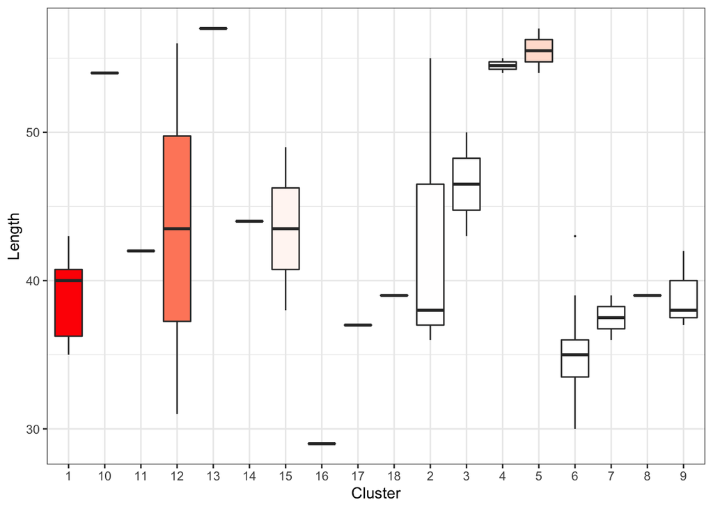

```r
ggplot(two,aes(x=as.character(ClusterIndex),y=Length,group=ClusterIndex,fill=as.numeric(Probability)))+
  geom_boxplot(outlier.size = 0.1)+theme_bw()+
  scale_fill_gradient(low = "red",high = "white")+
  theme(legend.position = 'none')+
  scale_x_discrete(name="Cluster")
```

Looking for specific family clusters that overlap inferred cohorts:

```r
#testing overlap
table(two.1$ClusterIndex%in%two.2$ClusterIndex)
```

```
##
## FALSE  TRUE
##    32     3
```

```r
table(two.2$ClusterIndex%in%two.1$ClusterIndex)
```

```
##
## FALSE  TRUE
##     6     2
```

```r
#comparing families
table(two.1$ClusterIndex)
```

```
##
##  1  2  3  6  7  8  9 11 12 14 15 16 17 18
##  6  2  2 11  2  1  3  1  1  1  2  1  1  1
```

```r
table(two.2$ClusterIndex)
```

```
##
##  2  4  5 10 12 13
##  1  2  2  1  1  1
```